# Exercise 01 — Running the Super Simple Ecosystem Model

Fluxcourse 2026 · Bloomington, Indiana

```r
# Reproducibility header: record when this document was knitted, which
# commit of the repository it came from, and the full R environment.
# This block runs automatically every time you knit and appears in the HTML.
cat("Date:", format(Sys.time(), "%Y-%m-%d %H:%M"), "\n")
```

```
## Date: 2026-06-08 13:06
```

```r
cat("Commit:", system("git rev-parse --short HEAD", intern = TRUE), "\n")
```

```
## Commit: c99ab96
```

## Introduction

In the lectures you heard how most land surface models (LSMs) share a common conceptual skeleton: carbon enters the ecosystem through photosynthesis, gets partitioned among plant tissues, and eventually returns to the atmosphere via autotrophic and heterotrophic respiration. The Super Simple Ecosystem Model (SSEM) implements exactly that skeleton in its most stripped-down form. Incoming light drives a light-use-efficiency calculation of gross primary production (GPP); a fixed fraction of GPP is respired immediately as autotrophic respiration (Ra) and the remainder is allocated between leaf and wood growth; dead organic matter accumulates in a soil pool and decomposes at a rate set by air temperature and a Q10 temperature sensitivity. There is no energy balance, no water cycle, no nitrogen limitation, no phenology trigger, no multi-layer canopy. That radical simplicity is intentional: because every arrow of carbon can be traced from a single equation to a plotted output, SSEM is ideal for developing a rigorous intuition for what process-based models actually compute — and for diagnosing what goes wrong when they fail.

In this exercise you will run SSEM at **two temperate forest sites** for calendar year 2008, using only measured shortwave radiation and air temperature as meteorological drivers:

- **US-NR1** (Niwot Ridge, Colorado) — a subalpine evergreen needleleaf forest (ENF) dominated by subalpine fir, Engelmann spruce, and lodgepole pine at 3,050 m elevation. Continuous AmeriFlux measurements since 1998. ENF sites maintain their foliage year-round; the seasonal carbon cycle is driven primarily by temperature and snowpack rather than leaf-on/leaf-off phenology.
- **US-MMS** (Morgan Monroe State Forest, Indiana) — a temperate deciduous broadleaf forest (DBF) in the Midwest, dominated by sugar maple, tulip poplar, and white oak. You visited this site on Friday. DBF sites have near-zero carbon uptake in winter and a sharp spring green-up driven by photoperiod and temperature.

Comparing ENF and DBF is the central goal of this exercise. By running the same model structure at both sites with vegetation-type-appropriate parameters, you can see which aspects of the carbon cycle SSEM captures across forest types — and which it cannot. You are not yet comparing against observations; that is Exercise 02. The goal here is to build a clear mental picture of what SSEM simulates and what it deliberately ignores.

## Setup

```r
# ── Libraries ─────────────────────────────────────────────────────────────────
# tidyverse loads dplyr (data manipulation), ggplot2 (figures), readr (fast
# CSV loading), tidyr (reshaping), and several other packages in one call.
library(tidyverse)

# lubridate provides convenient date-time parsing and arithmetic.
# We use it to parse FLUXNET ISO 8601 timestamps and filter by calendar year.
library(lubridate)

# ── Paths ─────────────────────────────────────────────────────────────────────
# Set this to your local data folder path.
# Example for Google Drive on Mac:
# data_dir <- "~/Google Drive/My Drive/Fluxcourse/.../Tuesday_AM_SSEM_part1"
data_dir <- "../data"  # default for codespace

# code_dir points to the R/ folder containing functions.R and utils.R.
code_dir <- "../R"

# ── Source the model code ─────────────────────────────────────────────────────
# R/functions.R contains the full SSEM implementation:
#   SSEM()              — core model: one 30-minute carbon cycle step
#   ensemble_forecast() — runs SSEM forward through an entire driver time series
#                         NOTE: uses 'ne' from the global environment (see Chunk 3)
#   ParticleFilter()    — sequential data assimilation (used in Exercise 02)
#   plot_forecast()     — 12-panel output summary with uncertainty envelopes
#   plot_params()       — diagnostic density plots of parameter distributions
#   rdirichlet.orig()   — draws from a Dirichlet distribution; used to sample
#                         carbon allocation fractions that must sum to 1
#   beta.match()        — Beta distribution moment matching for turnover priors
#   flux.uncertainty()  — heteroskedastic flux error model (Exercise 02)
#   varnames, units     — character vectors naming the 12 model output variables
source(file.path(code_dir, "functions.R"))

# R/utils.R contains lower-level helper functions:
#   ciEnvelope()    — draws a shaded credible interval polygon on a base R plot
#   col.alpha()     — adds alpha transparency to a colour specification
#   wtd.quantile()  — quantile function that respects particle filter weights
#   solar_geom()    — computes potential top-of-atmosphere shortwave radiation
#   mat2mcmc.list() — converts parameter matrices to CODA mcmc.list objects
source(file.path(code_dir, "utils.R"))
```

## Load and inspect drivers — US-NR1 (ENF, subalpine)

```r
# ── Read the US-NR1 site data ─────────────────────────────────────────────────
# US-NR1 is a subalpine evergreen needleleaf forest at Niwot Ridge, Colorado
# (3,050 m elevation), dominated by subalpine fir (Abies lasiocarpa), Engelmann
# spruce (Picea engelmannii), and lodgepole pine (Pinus contorta).  Continuous
# AmeriFlux tower measurements have been made since 1998.
#
# The _HH_ suffix denotes the half-hourly product: one row per 30-minute
# period, 48 rows per calendar day.  The ICOS/FLUXNET convention uses _HH_ for
# half-hourly data; earlier AmeriFlux product versions used _HR_ for this file.
# This repository uses _HH_ throughout to distinguish it from US-MMS which
# is genuinely hourly (_HR_).  The timestamp column is DATETIME_START in
# ISO 8601 format (same as the European FLUXNET sites DE-Tha and DK-Sor).
nr1_raw <- read_csv(
  file.path(data_dir, "US-NR1", "US-NR1_HH.csv"),
  show_col_types = FALSE
)

# FLUXNET uses -9999 as a sentinel for missing observations (not the same as
# a true zero). Replace these with NA so R treats them as missing data rather
# than including them in calculations.
nr1_raw <- nr1_raw |>
  mutate(across(where(is.numeric), \(x) replace(x, x == -9999, NA)))

# ── Filter to calendar year 2008 ──────────────────────────────────────────────
# Year 2008 is a clean mid-record year at US-NR1 with good data coverage and
# no major disturbance events, giving a representative seasonal cycle.
# 2008 is a leap year: 366 days × 48 half-hour periods = 17,568 rows.
drivers_nr1 <- nr1_raw |>
  mutate(
    # readr auto-parses DATETIME_START as POSIXct (it recognises the ISO 8601
    # format).  Using the column directly — without ymd_hms() re-parsing — is
    # the correct approach; calling ymd_hms() on a POSIXct column triggers an
    # internal as.character() round-trip that drops ~366 timestamps per year.
    datetime = DATETIME_START
  ) |>
  filter(year(datetime) == 2008) |>
  select(datetime, SW_IN_F, TA_F)

# Confirm the expected row count: 366 days × 48 steps = 17,568 for a leap year.
cat("US-NR1 timesteps in 2008:", nrow(drivers_nr1),
    "(expect 17,568 for a leap year)\n")
```

```
## US-NR1 timesteps in 2008: 17568 (expect 17,568 for a leap year)
```

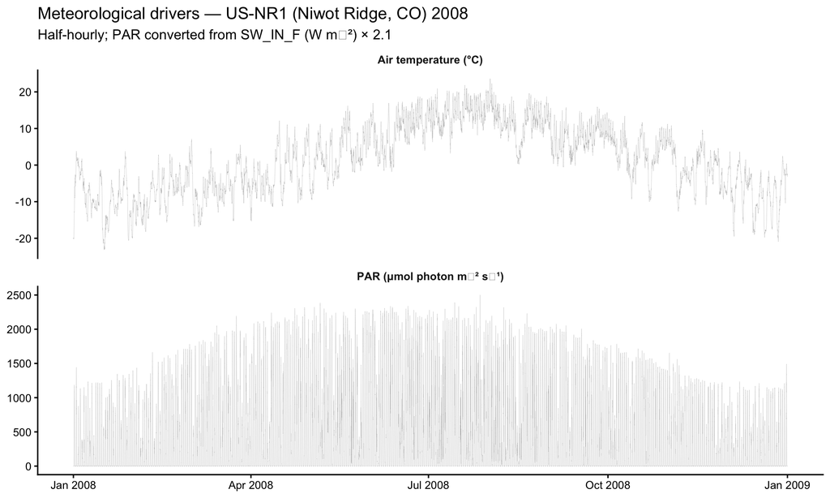

```r
# ── Convert to model input units ──────────────────────────────────────────────
# SSEM's photosynthesis routine expects exactly two driver columns:
#   PAR  — photosynthetically active radiation (μmol photon m⁻² s⁻¹)
#   temp — air temperature (°C)
#
# SW_IN_F is gap-filled incoming shortwave radiation in W m⁻².
# PAR occupies the 400–700 nm waveband, roughly 45% of total shortwave.
# Within that waveband, 1 W m⁻² ≈ 4.6 μmol photons.
# Combined: PAR (μmol m⁻² s⁻¹) ≈ SW_IN_F (W m⁻²) × 0.45 × 4.6 ≈ SW_IN_F × 2.1
# We floor at 0 because sensors occasionally report tiny negative values at night
# due to calibration drift; the model does not allow negative PAR.
#
# TA_F is gap-filled air temperature already in °C — no unit conversion needed.
drivers_nr1 <- drivers_nr1 |>
  mutate(
    PAR  = pmax(SW_IN_F * 2.1, 0),
    temp = TA_F
  )

# ── Plot the US-NR1 drivers ───────────────────────────────────────────────────
drivers_nr1 |>
  select(datetime, PAR, temp) |>
  pivot_longer(
    cols      = c(PAR, temp),
    names_to  = "variable",
    values_to = "value"
  ) |>
  mutate(
    label = case_when(
      variable == "PAR"  ~ "PAR (μmol photon m⁻² s⁻¹)",
      variable == "temp" ~ "Air temperature (°C)"
    )
  ) |>
  ggplot(aes(x = datetime, y = value)) +
    geom_line(linewidth = 0.1, alpha = 0.35, colour = "grey20") +
    facet_wrap(~ label, ncol = 1, scales = "free_y") +
    labs(
      title    = "Meteorological drivers — US-NR1 (Niwot Ridge, CO) 2008",
      subtitle = "Half-hourly; PAR converted from SW_IN_F (W m⁻²) × 2.1",
      x        = NULL,
      y        = NULL
    ) +
    theme_classic(base_size = 12) +
    theme(strip.background = element_blank(),
          strip.text        = element_text(face = "bold"))
```

## Load and inspect drivers — US-MMS (DBF, temperate)

```r
# ── Read the US-MMS site data ─────────────────────────────────────────────────
# US-MMS is a temperate mixed deciduous broadleaf forest at Morgan Monroe State
# Forest in Indiana.  You visited this site on Friday.  The dominant species are
# sugar maple (Acer saccharum), tulip poplar (Liriodendron tulipifera), and
# white oak (Quercus alba).
#
# US-MMS uses the AmeriFlux _HR_ hourly product: one row per 60 minutes,
# 24 rows per calendar day.  The timestamp column is TIMESTAMP_START in integer
# format YYYYMMDDHHMM — different from the ISO 8601 format at US-NR1.
# See the timestep note below for why the 60-minute step matters.
mms_raw <- read_csv(
  file.path(data_dir, "US-MMS", "US-MMS_HR.csv"),
  show_col_types = FALSE
)

# Replace FLUXNET missing-value sentinel with NA.
mms_raw <- mms_raw |>
  mutate(across(where(is.numeric), \(x) replace(x, x == -9999, NA)))

# ── Filter to calendar year 2008 ──────────────────────────────────────────────
# We use 2008 at US-MMS for consistency with US-NR1.
# 2008 is a leap year: 366 days × 24 hourly periods = 8,784 rows.
drivers_mms <- mms_raw |>
  mutate(
    # TIMESTAMP_START is an integer in YYYYMMDDHHMM format.
    # as.character() converts the integer to a string so as.POSIXct()
    # can parse it with the explicit format string.
    datetime = as.POSIXct(
      as.character(TIMESTAMP_START),
      format = "%Y%m%d%H%M",
      tz     = "UTC"
    )
  ) |>
  filter(year(datetime) == 2008) |>
  select(datetime, SW_IN_F, TA_F)

# Confirm the expected row count.
cat("US-MMS timesteps in 2008:", nrow(drivers_mms),
    "(expect 8,784 for a leap year at hourly resolution)\n")
```

```
## US-MMS timesteps in 2008: 8784 (expect 8,784 for a leap year at hourly resolution)
```

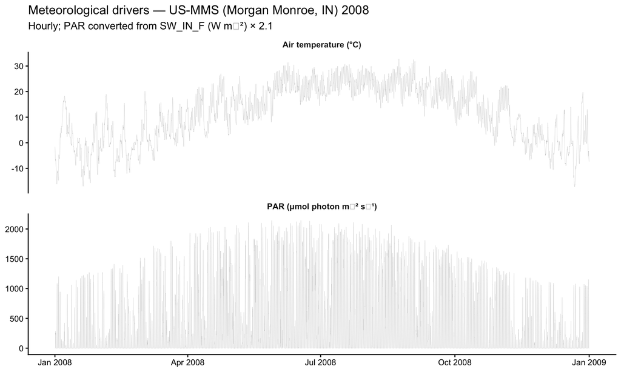

```r
# ── Convert to model input units ──────────────────────────────────────────────
# Same PAR conversion as US-NR1: SW_IN_F (W m⁻²) × 2.1 → μmol photon m⁻² s⁻¹.
# TA_F is already in °C.
drivers_mms <- drivers_mms |>
  mutate(
    PAR  = pmax(SW_IN_F * 2.1, 0),
    temp = TA_F
  )

# ┌─────────────────────────────────────────────────────────────────────────────┐
# │  TIMESTEP NOTE — important for unit conversions in Exercise 02              │
# │                                                                             │
# │  US-NR1 is half-hourly: 48 rows per day, 1800 seconds per timestep.        │
# │  US-MMS is hourly:      24 rows per day, 3600 seconds per timestep.        │
# │                                                                             │
# │  SSEM itself has no fixed timestep requirement — it loops over whatever    │
# │  rows you supply.  But the number of rows per day affects two things:      │
# │                                                                             │
# │  1. The x-axis of plot_forecast() counts timestep numbers, not dates.      │
# │     For US-NR1, step 48 = end of day 1; for US-MMS it is step 24.         │
# │                                                                             │
# │  2. In Exercise 02, converting model output from μmol m⁻² s⁻¹ (a rate)   │
# │     to gC m⁻² day⁻¹ (a daily total) requires multiplying by the step      │
# │     length in seconds: 1800 s for US-NR1, 3600 s for US-MMS.              │
# │     Using the wrong value introduces a factor-of-two error in daily totals │
# │     — easy to miss, hard to diagnose in a plot.                            │
# └─────────────────────────────────────────────────────────────────────────────┘

# ── Plot the US-MMS drivers ───────────────────────────────────────────────────
drivers_mms |>
  select(datetime, PAR, temp) |>
  pivot_longer(
    cols      = c(PAR, temp),
    names_to  = "variable",
    values_to = "value"
  ) |>
  mutate(
    label = case_when(
      variable == "PAR"  ~ "PAR (μmol photon m⁻² s⁻¹)",
      variable == "temp" ~ "Air temperature (°C)"
    )
  ) |>
  ggplot(aes(x = datetime, y = value)) +
    geom_line(linewidth = 0.1, alpha = 0.35, colour = "grey20") +
    facet_wrap(~ label, ncol = 1, scales = "free_y") +
    labs(
      title    = "Meteorological drivers — US-MMS (Morgan Monroe, IN) 2008",
      subtitle = "Hourly; PAR converted from SW_IN_F (W m⁻²) × 2.1",
      x        = NULL,
      y        = NULL
    ) +
    theme_classic(base_size = 12) +
    theme(strip.background = element_blank(),
          strip.text        = element_text(face = "bold"))
```

## Parameters and initial conditions — US-NR1 (ENF)

```r
# ── Ensemble size ─────────────────────────────────────────────────────────────
# ensemble_forecast() reads 'ne' from the global environment — it must be
# defined before you call the function.
ne <- 100

# Fix the random seed so your results match this document exactly.
set.seed(2026)

# ── Initial carbon pool sizes for US-NR1 ─────────────────────────────────────
# SSEM tracks three carbon pools, all in Mg C ha⁻¹:
#   column 1 — Bleaf:  leaf carbon
#   column 2 — Bwood:  wood (stem + coarse root) carbon
#   column 3 — BSOM:   soil organic carbon
#
# Values below represent a mature subalpine ENF stand at Niwot Ridge.
X_nr1 <- matrix(NA_real_, nrow = ne, ncol = 3)
# Bleaf: needle carbon (Mg C ha⁻¹). Subalpine spruce/fir needles live 4–8 years;
# at any time several needle cohorts are present. Typical ENF: 2–5 Mg C ha⁻¹.
X_nr1[, 1] <- 3.0
# Bwood: stem + coarse root carbon. Subalpine ENF at US-NR1: 80–130 Mg C ha⁻¹.
X_nr1[, 2] <- 100.0
# BSOM: soil organic carbon to 1 m depth. Subalpine soils accumulate organic
# matter slowly due to cold temperatures; 80–120 Mg C ha⁻¹ is a reasonable range.
X_nr1[, 3] <- 100.0

# ── ENF parameter ensemble (US-NR1, spruce/fir) ───────────────────────────────
# Parameter values are appropriate for a subalpine ENF.  Compared with a DBF:
#   • Longer needle longevity → lower litterfall rate
#   • Similar wood turnover
#   • CUE (NPP/GPP) slightly lower → higher Ra fraction
#   • Similar alpha and SLA to other cold-climate conifers
params_nr1 <- data.frame(

  # α: canopy light use efficiency (μmol CO₂ per μmol photon absorbed)
  # GPP = α × Beer's law × PAR
  # Subalpine conifers: 0.015–0.025 μmol μmol⁻¹ (slightly lower than
  # low-elevation sites due to high-elevation UV and cold stress).
  alpha = rnorm(ne, mean = 0.02, sd = 0.003) |> pmax(0),

  # SLA: specific leaf area (m² leaf per kg leaf dry mass)
  # Conifer needles are thicker and denser than broadleaf leaves.
  # Engelmann spruce / subalpine fir: 4–10 m² kg⁻¹.
  SLA = rnorm(ne, mean = 8.0, sd = 1.2) |> pmax(1),

  # Rbasal: basal heterotrophic respiration rate
  # Rh = Rbasal × BSOM × Q10^(temp / 10)
  # Cold subalpine soils decompose slowly; Rbasal is similar to other sites
  # because it is calibrated against the actual soil carbon pool size.
  Rbasal = rnorm(ne, mean = 0.015, sd = 0.003) |> pmax(0),

  # Q10: temperature sensitivity of heterotrophic respiration (dimensionless)
  # High-elevation soils show similar Q10 to low-elevation sites.
  Q10 = rnorm(ne, mean = 2.0, sd = 0.3) |> pmax(1),

  # litterfall: fraction of leaf C transferred to BSOM per 30-min timestep
  # Subalpine fir needles live ~4 years → ~25% annual turnover.
  # Per 30-min step: 0.25 / (365 × 48) ≈ 1.4 × 10⁻⁵
  litterfall = rnorm(ne, mean = 1.4e-5, sd = 1.5e-6) |> pmax(0),

  # mortality: fraction of wood C transferred to BSOM per 30-min timestep
  # ~80-year natural stand rotation → ~1.25% yr⁻¹.
  # Per 30-min step: 0.0125 / (365 × 48) ≈ 7.1 × 10⁻⁷
  mortality = rnorm(ne, mean = 7.1e-7, sd = 7e-8) |> pmax(0),

  sigma.leaf = rep(0.01, ne),
  sigma.stem = rep(0.10, ne),
  sigma.soil = rep(0.10, ne)
)

# Carbon allocation fractions for an ENF (Dirichlet concentration parameters):
#   falloc.1 → Ra (autotrophic respiration)  : 5 / 10 = 50% expected
#   falloc.2 → NPPwood (wood growth)         : 3 / 10 = 30% expected
#   falloc.3 → NPPleaf (leaf growth)         : 2 / 10 = 20% expected
#
# Carbon use efficiency (CUE = NPP/GPP) for ENF ≈ 0.50.  Evergreen conifers
# invest less in leaf rebuilding than deciduous trees.
falloc_nr1 <- rdirichlet.orig(ne, alpha = c(5, 3, 2))
params_nr1$falloc.1 <- falloc_nr1[, 1]
params_nr1$falloc.2 <- falloc_nr1[, 2]
params_nr1$falloc.3 <- falloc_nr1[, 3]

stopifnot(
  all(abs(rowSums(params_nr1[, c("falloc.1", "falloc.2", "falloc.3")]) - 1) < 1e-10)
)

cat("\nUS-NR1 ENF parameter ensemble: mean ± SD across", ne, "members\n")
```

```
##
## US-NR1 ENF parameter ensemble: mean ± SD across 100 members
```

```r
cat(sprintf("  %-12s  %10s  %10s\n", "parameter", "mean", "SD"))
```

```
##   parameter           mean          SD
```

```r
cat(rep("-", 38), "\n", sep = "")
for (p in names(params_nr1)) {
  cat(sprintf("  %-12s  %10.3g  %10.3g\n", p, mean(params_nr1[[p]]), sd(params_nr1[[p]])))
}
```

```
##   alpha             0.0197     0.00301
##   SLA                 8.15        1.15
##   Rbasal            0.0153     0.00265
##   Q10                 1.98       0.316
##   litterfall      1.42e-05    1.78e-06
##   mortality       7.21e-07    6.33e-08
##   sigma.leaf          0.01           0
##   sigma.stem           0.1           0
##   sigma.soil           0.1           0
##   falloc.1           0.335        0.19
##   falloc.2           0.328       0.191
##   falloc.3           0.337       0.189
```

## Parameters and initial conditions — US-MMS (DBF)

```r
# ── Initial carbon pool sizes for US-MMS ──────────────────────────────────────
# Representative values for a mature mixed deciduous broadleaf forest in Indiana.
X_mms <- matrix(NA_real_, nrow = ne, ncol = 3)
# Bleaf: leaf carbon. Deciduous forests rebuild their canopy from scratch each
# spring; at peak leaf-out, Bleaf ≈ 1–4 Mg C ha⁻¹ for a mature stand.
X_mms[, 1] <- 3.0
# Bwood: stem + coarse root carbon. Old-growth mixed hardwood: 80–130 Mg C ha⁻¹.
X_mms[, 2] <- 100.0
# BSOM: soil organic carbon. Thick deciduous leaf litter contributes to high
# SOM stocks; 80–120 Mg C ha⁻¹ is consistent with southern Indiana NRCS data.
X_mms[, 3] <- 100.0

# ── DBF parameter ensemble (US-MMS, deciduous broadleaf) ──────────────────────
# The key difference from the ENF ensemble is leaf longevity:
#   ENF: needles live ~4 years → litterfall ≈ 0.25 / (365×48) ≈ 1.4×10⁻⁵ per step
#   DBF: leaves live ~1 year  → litterfall ≈ 1.0  / (365×48) ≈ 5.7×10⁻⁵ per step
# This 4× higher litterfall rate reflects that deciduous trees rebuild their
# full canopy from scratch every spring.  It also means Bleaf is more dynamic
# in the DBF run: the model will show a larger spring increase in Bleaf.
#
# The carbon allocation fractions also differ:
#   ENF: c(5,3,2) → Ra 50% | NPPwood 30% | NPPleaf 20%
#   DBF: c(4,3,3) → Ra 40% | NPPwood 30% | NPPleaf 30%
# The higher leaf allocation (30% vs 20%) reflects the cost of rebuilding the
# full deciduous canopy each year.

lf_annual_dbf <- 1.0    # yr⁻¹: 100% annual leaf turnover for a deciduous tree
steps_per_yr_hh <- 365L * 48L   # 17,520 half-hourly steps in a non-leap year

params_mms <- data.frame(

  # alpha: canopy light use efficiency
  # Growing-season LUE of temperate broadleaf forests broadly similar to ENF.
  alpha = rnorm(ne, mean = 0.02, sd = 0.003) |> pmax(0),

  # SLA: specific leaf area. Deciduous broadleaf trees have thinner leaves;
  # oak/maple typical range: 12–25 m² kg⁻¹. Using 15.0 as prior mean.
  SLA = rnorm(ne, mean = 15.0, sd = 2.0) |> pmax(1),

  # Rbasal: basal heterotrophic respiration rate. Indiana soils are warmer
  # on average than subalpine Colorado; using same prior as a neutral start.
  Rbasal = rnorm(ne, mean = 0.015, sd = 0.003) |> pmax(0),

  # Q10: temperature sensitivity of heterotrophic respiration.
  Q10 = rnorm(ne, mean = 2.0, sd = 0.3) |> pmax(1),

  # litterfall: deciduous ~1-year leaf longevity.
  # Per 30-min step: 1.0 / (365 × 48) ≈ 5.71 × 10⁻⁵
  litterfall = rnorm(
    ne,
    mean = lf_annual_dbf / steps_per_yr_hh,
    sd   = lf_annual_dbf * 0.1 / steps_per_yr_hh
  ) |> pmax(0),

  # mortality: same woody turnover rate as ENF.
  mortality = rnorm(ne, mean = 7.1e-7, sd = 7e-8) |> pmax(0),

  sigma.leaf = rep(0.01, ne),
  sigma.stem = rep(0.10, ne),
  sigma.soil = rep(0.10, ne)
)

# Carbon allocation fractions for a DBF:
#   falloc.1 → Ra   (autotrophic respiration): 4 / 10 = 40%
#   falloc.2 → NPPwood (wood growth):          3 / 10 = 30%
#   falloc.3 → NPPleaf (leaf growth):          3 / 10 = 30%
# Higher CUE than ENF (0.60 vs 0.50) is consistent with observations in
# deciduous forests (Malhi 2012).
falloc_mms <- rdirichlet.orig(ne, alpha = c(4, 3, 3))
params_mms$falloc.1 <- falloc_mms[, 1]
params_mms$falloc.2 <- falloc_mms[, 2]
params_mms$falloc.3 <- falloc_mms[, 3]

stopifnot(
  all(abs(rowSums(params_mms[, c("falloc.1", "falloc.2", "falloc.3")]) - 1) < 1e-10)
)

cat("\nUS-MMS DBF parameter ensemble: mean ± SD across", ne, "members\n")
```

```
##
## US-MMS DBF parameter ensemble: mean ± SD across 100 members
```

```r
cat(sprintf("  %-12s  %10s  %10s\n", "parameter", "mean", "SD"))
```

```
##   parameter           mean          SD
```

```r
cat(rep("-", 38), "\n", sep = "")
for (p in names(params_mms)) {
  cat(sprintf("  %-12s  %10.3g  %10.3g\n", p, mean(params_mms[[p]]), sd(params_mms[[p]])))
}
```

```
##   alpha             0.0201     0.00335
##   SLA                   15        1.76
##   Rbasal            0.0152     0.00324
##   Q10                 1.95       0.296
##   litterfall      5.74e-05    5.21e-06
##   mortality       7.13e-07    7.42e-08
##   sigma.leaf          0.01           0
##   sigma.stem           0.1           0
##   sigma.soil           0.1           0
##   falloc.1           0.341       0.146
##   falloc.2           0.314        0.14
##   falloc.3           0.345       0.152
```

## Run the model — US-NR1

```r
# ── Assemble inputs ───────────────────────────────────────────────────────────
inputs_nr1 <- drivers_nr1 |>
  select(PAR, temp) |>
  as.data.frame()

cat("US-NR1 input rows:", nrow(inputs_nr1), " | Expected (leap year):", 17568, "\n")
```

```
## US-NR1 input rows: 17568  | Expected (leap year): 17568
```

```r
# ── Run the ensemble ──────────────────────────────────────────────────────────
# ensemble_forecast() reads 'ne' from the global environment (set in Chunk 3).
# Run time: approximately 2–4 minutes on a modern laptop.
message("Starting US-NR1 model run — expect 2–4 minutes …")
```

```
## Starting US-NR1 model run — expect 2–4 minutes …
```

```r
output_nr1 <- ensemble_forecast(X_nr1, params_nr1, inputs_nr1)
```

```
## [1] 336
## [1] 672
## [1] 1008
## [1] 1344
## [1] 1680
## [1] 2016
## [1] 2352
## [1] 2688
## [1] 3024
## [1] 3360
## [1] 3696
## [1] 4032
## [1] 4368
## [1] 4704
## [1] 5040
```

[output cut: 37 more lines]

```r
cat("\nUS-NR1 output dimensions [timesteps × ensemble × variables]:\n")
```

```
##
## US-NR1 output dimensions [timesteps × ensemble × variables]:
```

```r
print(dim(output_nr1))
```

```
## [1] 17568   100    12
```

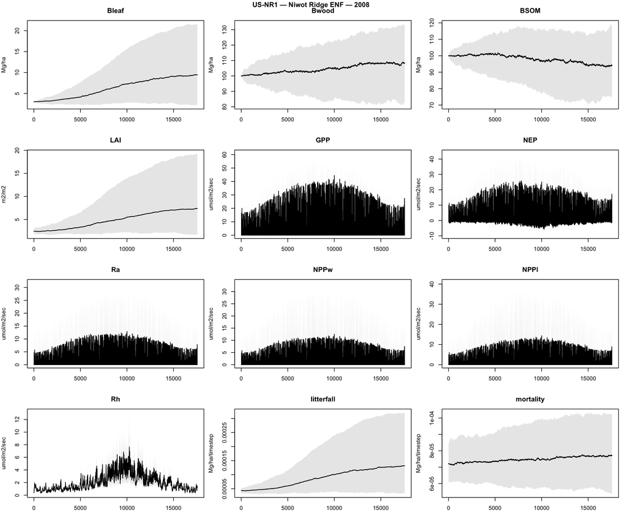

SSEM ensemble output for US-NR1 (Niwot Ridge, CO) 2008. Grey envelope: 95% credible interval across 100 ensemble members. Dark line: ensemble median. x-axis: 30-minute timestep number (48 steps = 1 day; 17,568 steps = full leap year).

```r
# ── Plot all 12 output variables ──────────────────────────────────────────────
par(mfrow = c(4, 3), mar = c(3, 4, 3, 0.5))
plot_forecast(output_nr1)
title(main = "US-NR1 — Niwot Ridge ENF — 2008", outer = TRUE, line = -1)
```

```r
par(mfrow = c(1, 1), mar = c(5, 4, 4, 2) + 0.1)

# ── Save output for Exercise 02 ───────────────────────────────────────────────
saveRDS(output_nr1, file.path(data_dir, "ssem_usnr1_2008.rds"))
message("Saved SSEM output → ", file.path(data_dir, "ssem_usnr1_2008.rds"))
```

```
## Saved SSEM output → ../data/ssem_usnr1_2008.rds
```

## Run the model — US-MMS

```r
# ── Assemble inputs ───────────────────────────────────────────────────────────
inputs_mms <- drivers_mms |>
  select(PAR, temp) |>
  as.data.frame()

cat("US-MMS input rows:", nrow(inputs_mms), " | Expected (leap year hourly):", 8784, "\n")
```

```
## US-MMS input rows: 8784  | Expected (leap year hourly): 8784
```

```r
# ── Run the ensemble ──────────────────────────────────────────────────────────
# US-MMS has 8,784 hourly timesteps (vs 17,568 half-hourly for US-NR1).
# Expected run time: approximately 1–2 minutes.
message("Starting US-MMS model run — expect 1–2 minutes …")
```

```
## Starting US-MMS model run — expect 1–2 minutes …
```

```r
output_mms <- ensemble_forecast(X_mms, params_mms, inputs_mms)
```

```
## [1] 336
## [1] 672
## [1] 1008
## [1] 1344
## [1] 1680
## [1] 2016
## [1] 2352
## [1] 2688
## [1] 3024
## [1] 3360
## [1] 3696
## [1] 4032
## [1] 4368
## [1] 4704
## [1] 5040
## [1] 5376
## [1] 5712
## [1] 6048
## [1] 6384
## [1] 6720
## [1] 7056
## [1] 7392
## [1] 7728
## [1] 8064
## [1] 8400
## [1] 8736
```

```r
cat("\nUS-MMS output dimensions [timesteps × ensemble × variables]:\n")
```

```
##
## US-MMS output dimensions [timesteps × ensemble × variables]:
```

```r
print(dim(output_mms))
```

```
## [1] 8784  100   12
```

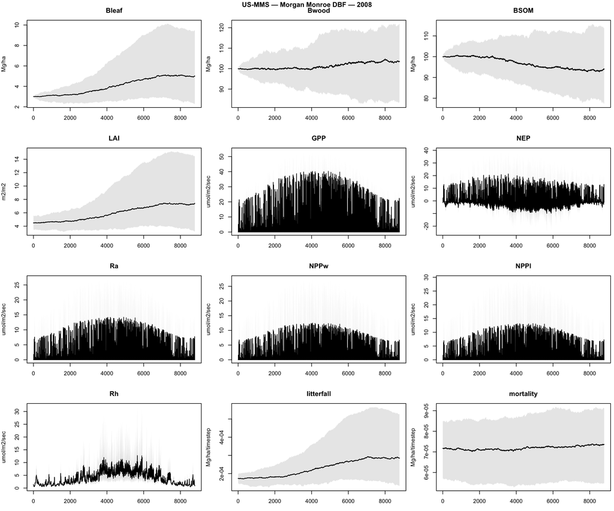

SSEM ensemble output for US-MMS (Morgan Monroe, IN) 2008. x-axis: hourly timestep number (24 steps = 1 day; 8,784 steps = full leap year at hourly resolution).

```r
# ── Plot all 12 output variables ──────────────────────────────────────────────
par(mfrow = c(4, 3), mar = c(3, 4, 3, 0.5))
plot_forecast(output_mms)
title(main = "US-MMS — Morgan Monroe DBF — 2008", outer = TRUE, line = -1)
```

```r
par(mfrow = c(1, 1), mar = c(5, 4, 4, 2) + 0.1)

# ── Save output for Exercise 02 ───────────────────────────────────────────────
saveRDS(output_mms, file.path(data_dir, "ssem_usmms_2008.rds"))
message("Saved SSEM output → ", file.path(data_dir, "ssem_usmms_2008.rds"))
```

```
## Saved SSEM output → ../data/ssem_usmms_2008.rds
```

## Discussion questions

Work through the following questions before moving on to Exercise 02. Compare the US-NR1 and US-MMS outputs side by side. There are no single correct answers; the goal is to reason from what you know about forest carbon cycling and what you can see in the model output panels above.

**1. GPP seasonality: ENF vs DBF.** Look at the GPP panels for both sites. Describe the seasonal trajectory of GPP at each site: when does it peak, when does it approach zero, and how sharp is the spring transition? US-NR1 is an evergreen conifer forest — unlike the deciduous trees at US-MMS, the spruce and fir at Niwot Ridge retain their needles year-round and can photosynthesize on warm winter days. Does the US-NR1 output reflect that possibility? SSEM has no explicit phenology trigger for leaf-on/leaf-off events. How does it produce any seasonal variation at all in the DBF run, and why is the spring green-up likely to look gradual rather than abrupt?

**2. Carbon pools and the litterfall difference.** Look at the Bleaf panels. The ENF and DBF runs use very different litterfall rates (1.4×10⁻⁵ vs 5.7×10⁻⁵ per 30-min step). Does this show up as a visible difference in the Bleaf trajectory? In the absence of an explicit phenology module, SSEM simulates seasonal leaf area change as the balance between NPPleaf allocation and the constant litterfall rate. What would happen to the Bleaf trajectory if you doubled the litterfall rate in the DBF run?

**3. Information needed to evaluate these outputs.** List the data streams that would allow you to assess whether the model output is realistic at each site, and for each one note: (a) which model variable or flux it constrains most directly, (b) the typical measurement uncertainty you would need to account for, and (c) any mismatch in temporal or spatial scale between the observation and the model output. Distinguish between observations that would be informative at both sites versus those that would be specific to only one vegetation type.

**4. Ensemble spread and forecast uncertainty.** Compare the width of the grey uncertainty envelopes across the 12 panels at each site. Which state variables or fluxes show the widest spread relative to their magnitude? Does the ENF or DBF run produce wider uncertainty envelopes? What does that pattern tell you about how the different parameter sets propagate uncertainty through the model?

## Optional extensions

Two additional European forest sites are available for further exploration. These sites are provided as extensions for students who want to compare SSEM across a broader range of temperate forest types.

- **DE-Tha** — Tharandt, Saxony, Germany. Norway spruce plantation (Picea abies), ENF. Half-hourly FLUXNET product; timestamp column DATETIME_START (ISO 8601). Year 2000 is the reference year used in older versions of this exercise. Data file: `data/DE-Tha/DE-Tha_HH.csv`
- **DK-Sor** — Sorø, Denmark. European beech forest (Fagus sylvatica), DBF. Half-hourly FLUXNET product; same timestamp format as DE-Tha. Contrast the sharp deciduous spring green-up at DK-Sor with the evergreen structure at DE-Tha. Data file: `data/DK-Sor/DK-Sor_HH.csv`